# Take-home Exercise 1

In this Take-home Exercise, I will explore the demographic of the city of Engagement, Ohio USA.

Che Xuan https://www.linkedin.com/in/jacob-che-xuan-b646a9123/  
2022-04-24

# Overview

In this take-home exercise, appropriate static statistical graphics methods are used to reveal the demographic of the [city of Engagement, Ohio USA](https://vast-challenge.github.io/2022/).

The data are processed by using appropriate **tidyverse** family of packages and the statistical graphics are prepared using **ggplot2** and its extensions.

# Sketch of Proposed Design

The picture below shows a sketch of the initial design proposed.

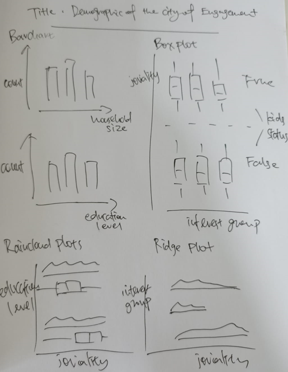

# Installing & Lauching R Packages

Before we get started, it is important for us to ensure that the required R packages have been installed. If yes, we will load the R packages. If they have yet to be installed, we will install the R packages and load them onto R environment.

The chunk code below will do the trick.

```r
packages = c('tidyverse', 'ggdist', 'ggridges', 'patchwork', 'ggthemes')

for(p in packages){
  if(!require(p, character.only = T)){
    install.packages(p)
  }
  library(p, character.only = T)
}
```

# Importing Data

The code chunk below imports *Participants.csv* from the data folder into R by using [`read_csv()`](https://readr.tidyverse.org/reference/read_delim.html) of [**readr**](https://readr.tidyverse.org/) package and save it as an tibble data frame called *participants*.

```r
participants <- read_csv("data/Participants.csv")

glimpse(participants)
```

```
Rows: 1,011
Columns: 7
$ participantId  <dbl> 0, 1, 2, 3, 4, 5, 6, 7, 8, 9, 10, 11, 12, 13,~
$ householdSize  <dbl> 3, 3, 3, 3, 3, 3, 3, 3, 3, 3, 3, 3, 3, 3, 3, ~
$ haveKids       <lgl> TRUE, TRUE, TRUE, TRUE, TRUE, TRUE, TRUE, TRU~
$ age            <dbl> 36, 25, 35, 21, 43, 32, 26, 27, 20, 35, 48, 2~
$ educationLevel <chr> "HighSchoolOrCollege", "HighSchoolOrCollege",~
$ interestGroup  <chr> "H", "B", "A", "I", "H", "D", "I", "A", "G", ~
$ joviality      <dbl> 0.001626703, 0.328086500, 0.393469590, 0.1380~
```

# Static Bar Chart

We will examine the household size as well as the education level of the participants in this data set. The code chunk below plots a bar chart by using `geom_bar()` of **ggplot2**.

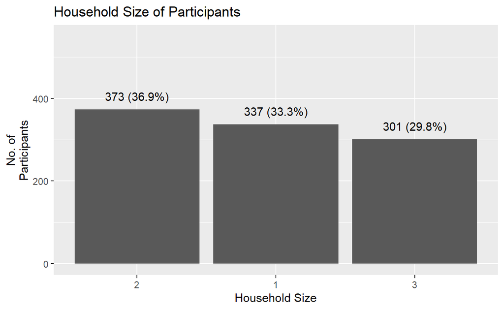

```r
ggplot(data = participants,
       aes(x=reorder(householdSize, householdSize, function(x)-length(x)))) +
  geom_bar() +
  ylim(0,550) +
  geom_text(stat="count",
      aes(label=paste0(..count.., " (",
      round(..count../sum(..count..)*100,
            1), "%)")),
      vjust=-1) +
  xlab("Household Size") +
  ylab("No. of\nParticipants") +
  ggtitle("Household Size of Participants")
```

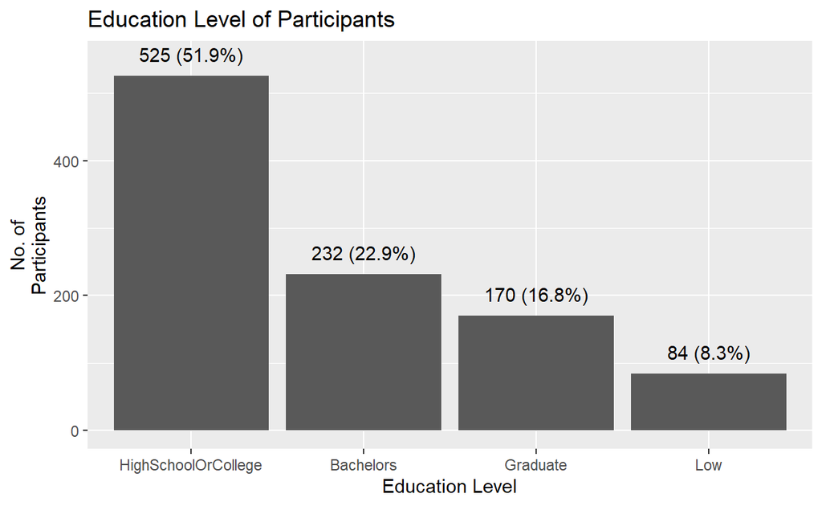

```r
ggplot(data = participants,
       aes(x=reorder(educationLevel, educationLevel, function(x)-length(x)))) +
  geom_bar() +
  ylim(0,550) +
  geom_text(stat="count",
      aes(label=paste0(..count.., " (",
      round(..count../sum(..count..)*100,
            1), "%)")),
      vjust=-1) +
  xlab("Education Level") +
  ylab("No. of\nParticipants") +
  ggtitle("Education Level of Participants")
```

# Static Trellis Boxplot

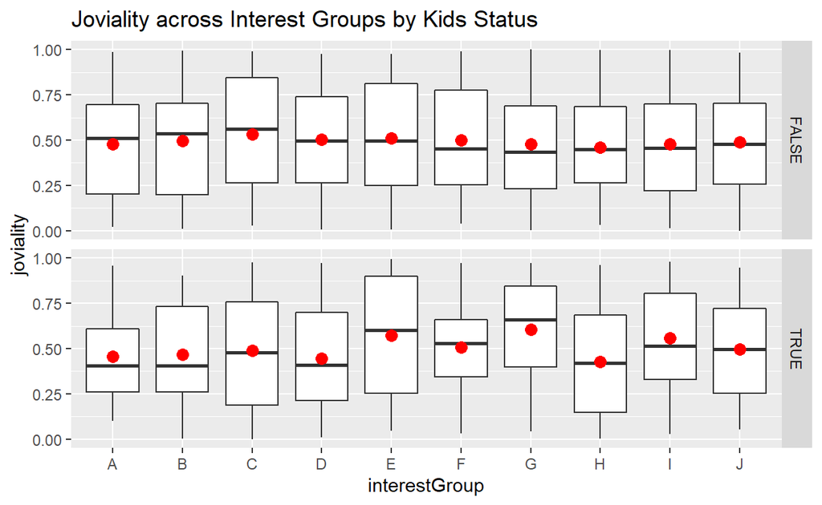

```r
ggplot(data=participants,
       aes(y = joviality, x= interestGroup)) +
  geom_boxplot() +
  stat_summary(geom = "point",
               fun.y="mean",
               colour ="red",
               size=3) +
  facet_grid(haveKids ~.) +
  ggtitle("Joviality across Interest Groups by Kids Status")
```

# Static Raincoud Plots

[*Joviality*](https://www.vocabulary.com/dictionary/joviality#:~:text=Joviality%20is%20the%20characteristic%20of,dinner%20might%20cheer%20you%20up.) is defined as the characteristic of being cheerful and festive. A higher joviality index would represent a greater level of cheerfulness.

We will examine the joviality spread of the participants across the education levels in this data set. The code chunk below creates raincloud plots by using `stat_halfeye()` of **ggdist** and `geom_boxplot()` of **ggplot2**.

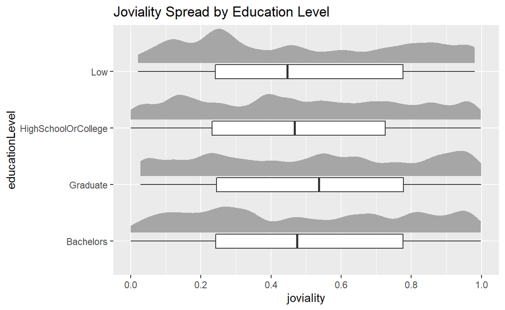

```r
ggplot(participants, aes(x = educationLevel, y = joviality)) +
  scale_y_continuous(breaks = seq(0, 1, 0.2),
                     limits = c(0, 1)) +
  stat_halfeye(adjust = .33,
               width = .67,
               color = NA,
               justification = -.01,
               position = position_nudge(
                 x = .15)
  ) +
  geom_boxplot(
    width = .25,
    outlier.shape = NA
  ) +
  coord_flip() +
  ggtitle("Joviality Spread by Education Level")
```

# Static Ridge Plot

We will examine the joviality spread of the participants across the interest groups in this data set. The code chunk below creates a ridge plot by using `geom_density_ridges()` of **ggridges**, an ggplot2 extension specially designed to create ridge plot.

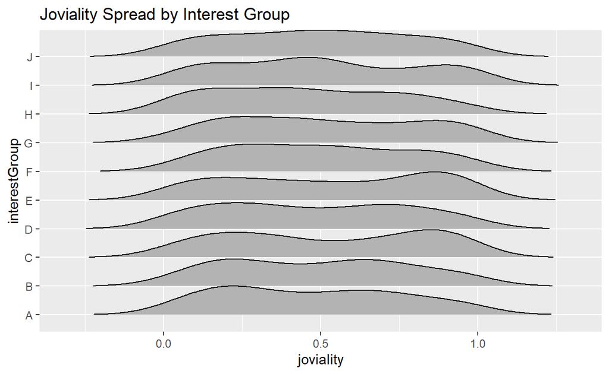

```r
ggplot(participants,
       aes(x = joviality, y = interestGroup)) +
  geom_density_ridges(rel_min_height = 0.01,
                      scale = 1) +
  ggtitle("Joviality Spread by Interest Group")
```

# Composite Plot

We will combine multiple plots together to have a dashboard view. The code chunk below creates a composite plot by using the **patchwork** package.

Note: p1 - p5 are assigned to plots as shown earlier.

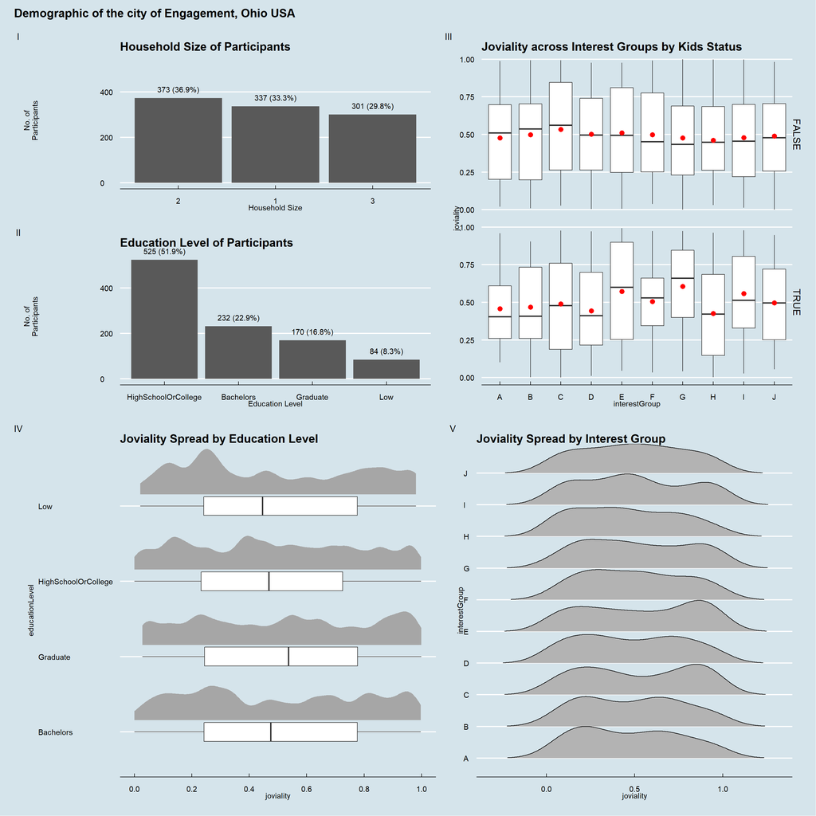

```r
patchwork <- ((p1 / p2)| p3)/(p4 | p5) +
              plot_annotation(tag_levels = 'I', title = 'Demographic of the city of Engagement, Ohio USA')
patchwork & theme_economist()
```